# Distributions In-Class Exercise

XDAS 2019 group effort

September 30, 2019

## Scenario

You want to clone a gene and you have some reporter for success of transformation in *E. coli*. Positive colonies are blue because they express $\beta$-galactosidase when plated on medium with IPTG. The probability of a successful transformation is $0 \le P(success) \le 1$. For the following exercise, you may consider one plate, many plates, or a truly gargantuan number of plates.

## Exercise

The class will split into 8 groups and each one will take one of the following distributions:

- Bernoulli
- Binomial
- Geometric
- Hypergeometric
- Negative binomial
- Poisson
- Normal
- Exponential

For your assigned distribution, answer the following questions. At the end of the class, each group will present their distribution and how it applies to the scenario above to the rest of the class.

## Bernoulli

#### Cassandra and Yen

##### Function Summary

$$PDF: \ \ f(x) = P(X=x) = \pi^x(1-\pi)^{1-x}, \ \ x \in \{0,1\}$$
where $\pi$ represents the probability of “success”, and ranges from zero to one: $0 \le \pi \le 1$.

Since $x$ can only take on values of 0 or 1, and there is only one trial, $f(x)$ can take on only one of two values:

$$f(1) = P(X=1) = \pi \ \ \ or \ \ \ f(0) = P(X=0) = 1-\pi$$

$$CDF: \ \ F(X) = \begin{cases}
1 - \pi & x = 0\\
1 & x = 1
\end{cases}$$

#### a. What is your function? Describe it in terms of the kind of problem that it applies to. Is it discrete or continuous?

*The function we choose is Bernoulli experiment. It’s a special case of binomial distribution where n = 1. It’s describing a single trial of a binary random variable. It applies to many of the experiments that we want to conceptualize the success rate (like cloning, transfection, gene editting, and etc.). It’s the basis of how we can estimate the probability of having a specific number of success (binomial), how many experiments we need before getting a or x success (negative binomial / geometric).*

*Bernoulli distribution is discrete.*

#### b. Describe a question that you can ask with your distribution as applied to the transformation scenario given above.

*With preliminary experiments to estimate the success rate $p$, in the transformation with reporterexperiment, we can use Bernoulli experiment to ask **how likely each bacterium will take in the plasmid and be transformed**, thus expressing the reporter gene LacZ or GFP.*

#### c. Describe the parameterization of the equation. What parameters does it take, and what do they mean?

*The PDF and CDF of Bernoulli distribution only takes $p$ (the success rate) and $x$ (the number of success cases, in which can only be 0 or 1), where the PDF is:*

$$P(x) = \begin{cases} p \quad{} if\quad{}x = 1\\\\1-p \quad{} if\quad{}x = 0 \end{cases}$$

*and the CDF is:*

$$F(x) = \begin{cases} 1 \quad{} if\quad{}x = 1\\\\1-p \quad{} if\quad{}x = 0 \end{cases}$$

#### d. Pick some appropriate parameters for your distribution as applied to the transformation scenario and graph the PDF and CDF.

*The transformation rate is ~23% ($p=\frac{4}{17}$).*

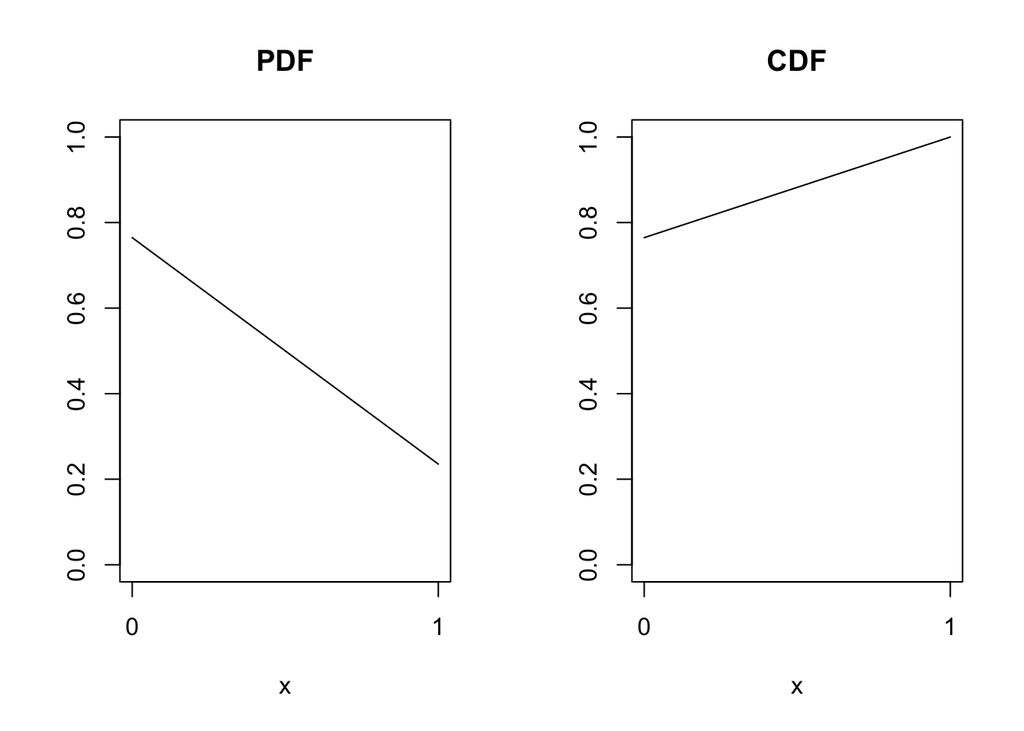

```r
set.seed(20190930)
par(mfrow = c(1,2))
plot(x= c(0, 1), y = dbinom(c(0, 1), 1, 4/17), type = "l",
     main = "PDF", xlab = "x", ylab = "", ylim = c(0, 1), xaxt='n')
axis(side = 1, at = c(0, 1))
plot(x= c(0, 1), y = pbinom(c(0, 1), 1, 4/17), type = "l",
     main = "CDF", xlab = "x", ylab = "", ylim = c(0, 1), xaxt='n')
axis(side = 1, at = c(0, 1))
```

#### e. Compute a cumulative probability for some appropriate value and describe in words what it means. Be prepared to explain your answer to the class.

*By definition, Bernoulli distribution only exist for $x\in{}\{0, 1\}$, so and it has a CDF:*

$$F(x) = \begin{cases} 1 \quad{} if\quad{}x = 1\\\\1-p \quad{} if\quad{}x = 0 \end{cases}$$

*It means that the cumulative chance to getting no success ($x = 0$) is $1-p$, while the chance of getting equal or less than 1 success is the sum of every possible case, thus $P(x = 1) = 1$.*

#### f. Identify at least one other distribution that yours relates to and be prepared to discuss the relationship between them. This could be a special case, a limiting case, an approximation, or an inverse CDF (survival) relationship.

*Binomial distribution can be seen as repeating Bernoulli trial for n times.*

## Binomial

#### Rebecca and Adhiti

##### Function Summary

$$X \sim BIN(n,\pi), \ with \ \mu = E(X) = np \ and \ \sigma^2 = V(X) = np(1-p)$$

$$PDF: \ \ f(x) = {n \choose x} \pi^x(1-\pi)^{n-x}, \ \ \ x \in \{0,1,...,n\}$$

$$CDF: \ \ F(X) = \sum_{x=0}^n{n \choose x}\pi^x(1-\pi)^{n-x} = 1$$

#### a. What is your function? Describe it in terms of the kind of problem that it applies to. Is it discrete or continuous?

*We have the binomial distribution, which is the binom function in R. This is a statistical method for describing the probability of successes and failures. It is asking a yes/no question. It is a discreet probability*

#### b. Describe a question that you can ask with your distribution as applied to the transformation scenario given above.

*Out of 10 experiments (n or number of experiments), how many positively transformed (via blue color) colonies are observed on a given plate (x or number of successes)?*

#### c. Describe the parameterization of the equation. What parameters does it take, and what do they mean?

*X ~ BIN(n,pi). It uses n for the number of trials and x for the overall number of successes*

#### d. Pick some appropriate parameters for your distribution as applied to the transformation scenario and graph the PDF and CDF.

```r
dbinom(1,10, (1/3))
```

```
## [1] 0.08670765
```

```r
# What is the probability of 1 success out of 10 trials given the probability of success is 1/3 in a single trial

dbinom(0:10, 10, (1/3))
```

```
##  [1] 1.734153e-02 8.670765e-02 1.950922e-01 2.601229e-01 2.276076e-01
##  [6] 1.365645e-01 5.690190e-02 1.625768e-02 3.048316e-03 3.387018e-04
## [11] 1.693509e-05
```

```r
#Then we wanted to know what the discrete probabilities would be for 0-10 trials given the observed probability of 1/3.
```

#### e. Compute a cumulative probability for some appropriate value and describe in words what it means. Be prepared to explain your answer to the class.

```r
pbinom(0:10, 10, (1/3))
```

```
##  [1] 0.01734153 0.10404918 0.29914139 0.55926434 0.78687192 0.92343647
##  [7] 0.98033836 0.99659605 0.99964436 0.99998306 1.00000000
```

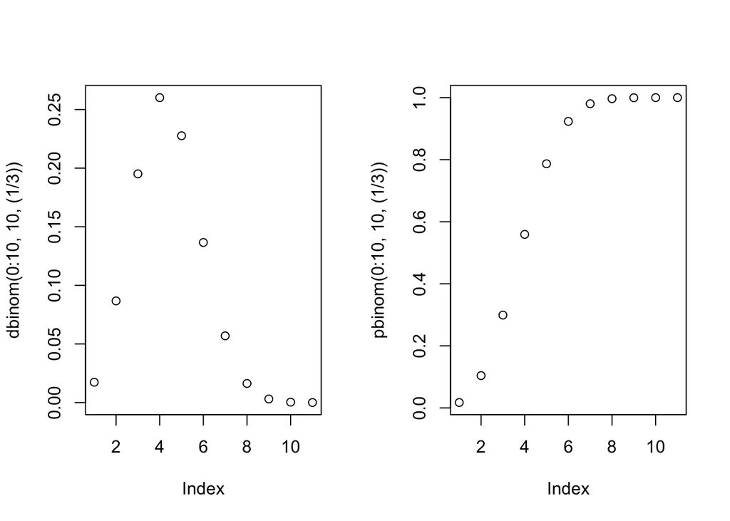

```r
par(mfrow = c(1,2))
plot(dbinom(0:10,10, (1/3)))
plot(pbinom(0:10,10, (1/3)))
```

*Here we have computed the cumultive probability or CDF of getting 0-10 successes out of 10 trials (adding the individual probabilities for each of the 10 trials).*

#### f. Identify at least one other distribution that yours relates to and be prepared to discuss the relationship between them. This could be a special case, a limiting case, an approximation, or an inverse CDF (survival) relationship.

*We could use a negative binomial distribution in order to check the faliure rate and see if it matches up*

## Geometric

#### Daniel and Larissa

##### Function Summary

$$X \sim GEO(p),\ \ E(x) = 1/p \ \ and \ \ Var(X) = (1-p)/p^2$$

The geometric distribution is a special case of the NB, where $r=1$: $X$ ~ $GEO(p)$ is equivalent to $X$ ~ $NB(1,p)$.

#### a. What is your function? Describe it in terms of the kind of problem that it applies to. Is it discrete or continuous?

*Geometric function: It gives the probability of getting x number of failures before a success*

#### b. Describe a question that you can ask with your distribution as applied to the transformation scenario given above.

*When randomly picking colonies from yor plate, what is the probability of getting 6 white colonies before getting a green one?*

#### c. Describe the parameterization of the equation. What parameters does it take, and what do they mean?

*The equation takes two parameters:* x - number of failures p - probability of success

#### d. Pick some appropriate parameters for your distribution as applied to the transformation scenario and graph the PDF and CDF.

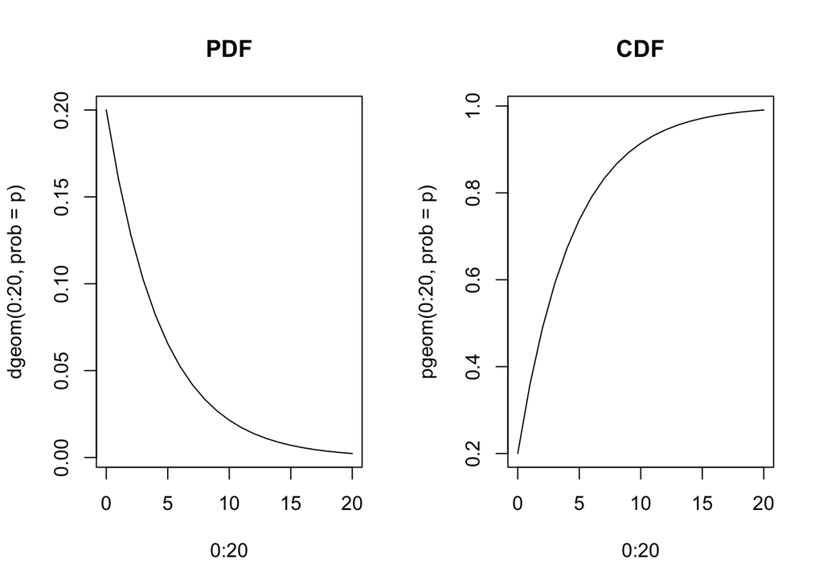

```r
p = 0.2
par(mfrow=c(1,2))
plot(0:20, dgeom(0:20,prob = p), type = "l", main = "PDF")
plot(0:20, pgeom(0:20,prob = p), type = "l", main = "CDF")
```

#### e. Compute a cumulative probability for some appropriate value and describe in words what it means. Be prepared to explain your answer to the class.

```r
pgeom(6,prob = p)
```

```
## [1] 0.7902848
```

*The probability of getting 6 and less white colonies before getting a green colony is 0.79.*

#### f. Identify at least one other distribution that yours relates to and be prepared to discuss the relationship between them. This could be a special case, a limiting case, an approximation, or an inverse CDF (survival) relationship.

*Negative binomial. The geometric function is a specific case of the negative binomial where r;number of successes is 1.*

## Hypergeometric

#### Jackie and Soobeom

##### Function Summary

$$X \sim HYP(n,M,N)$$
$$E(X) = nM/N, \ \ Var(X) = n \frac{M}{N} \left({1-\frac{M}{N}}\right) \frac{N-n}{N-1}$$

$$PDF: \ \ f(x) = P(X = x) = {M \choose x}{N - M \choose n - x}\bigg/{N \choose n}$$

where:

- $x \in \{0,1,2,...,n\}$ the number of successful trials
- $N \in \{1,2,...\}$ is the total number of selectable items
- $M \in \{0,1,2,...,N\}$ is the total number of possible successful outcomes (i.e. th number of items in the group of interest)
- $n \in \{0,1,2,...,N\}$ is the number of items sampled

#### a. What is your function? Describe it in terms of the kind of problem that it applies to. Is it discrete or continuous?

*Hyper Geometric: It is a discrete function and you sample without replacement from a universal value. Each trial outcome affects the outcome of the next trial.*

#### b. Describe a question that you can ask with your distribution as applied to the transformation scenario given above.

*There are 100 bacterial colonies on a plate. 25 colonies are blue and 75 colonies are white. If you take a sample 10 colonies, whats the probability of getting 10 blue transformed colonies after 10 trials?*

#### c. Describe the parameterization of the equation. What parameters does it take, and what do they mean?

*Hyper Geometric parameters:* N = 100 n = 10 x = 10 M = 25 <- blue M = 75 <- white

#### d. Pick some appropriate parameters for your distribution as applied to the transformation scenario and graph the PDF and CDF.

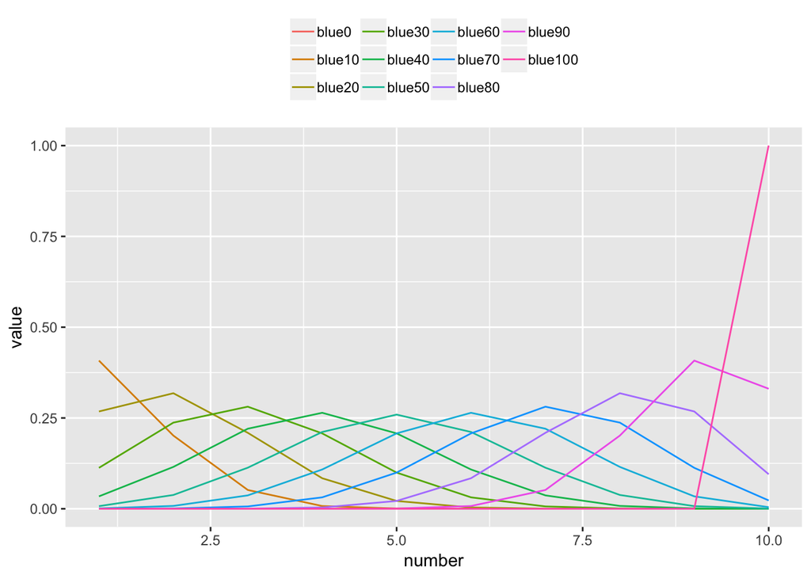

```r
library(ggplot2)
library(reshape2)

blue <- c(0,10,20,30,40,50,60,70,80,90,100) # our parameter

# make PDF
pdf <- NULL
for (i in blue){
  xx <- dhyper(1:10, i, 100-i, 10)
  pdf <- cbind(pdf, xx)
}

colnames(pdf) <- paste("blue", blue, sep = "")

# make CDF
cdf <- NULL
for (i in blue){
  xx <- phyper(1:10, i, 100-i, 10)
  cdf <- cbind(cdf, xx)
}

colnames(cdf) <- paste("blue", blue, sep = "")

# make dataframe for ggplot
pdf2 <- data.frame(pdf, number=1:10)
pdf2 <- melt(pdf2, "number")
cdf2 <- data.frame(cdf, number=1:10)
cdf2 <- melt(cdf2, "number")

# plot PDF with 10 different parameters
ggplot()+
  geom_line(aes(y = value, x = number, colour = variable),
                     data = pdf2, stat="identity") +
  theme(legend.title = element_blank(),
        legend.position="top")
```

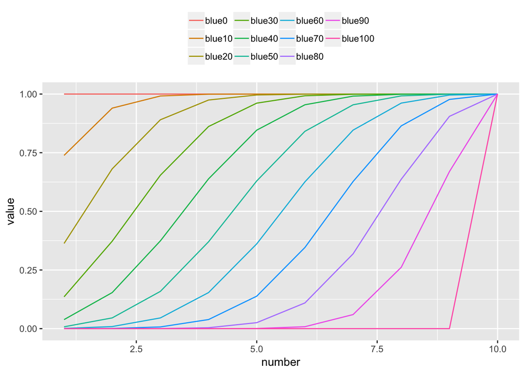

```r
# plot CDF with 10 different parameters
ggplot()+
  geom_line(aes(y = value, x = number, colour = variable),
            data = cdf2, stat="identity") +
  theme(legend.title = element_blank(),
        legend.position="top")
```